# Actividdad 1 - Preproceso de datos

Jorge Alonso Hernández

21 de October, 2021

# 1. Carga del archivo

Para iniciar la carga del fichero primero revisamos el documento facilitado para comprobar el separador utilizado, comprobando que el separador utilizado es “;”.

Generaremos una variable a la que denominaremos “ruta_csv” que almacenará la ruta a nuestro fichero, la cual obtendremos con la función:

```
file.choose()
```

Una vez tenemos la dirección del fichero realizamos la carga del fichero

```r
ruta_csv <- "C:\\Users\\Jorge\\Desktop\\Rstudio Workspace\\Estadística Avanzada\\Actividad 1\\train3.csv"
seguros <- read.csv2(ruta_csv,na.strings="NA")

sapply(seguros,class)
```

```
##               ClaimNumber        DateTimeOfAccident              DateReported
##               "character"               "character"               "character"
##                       Age                    Gender             MaritalStatus
##                 "integer"               "character"               "character"
##         DependentChildren           DependentsOther               WeeklyWages
##                 "integer"                 "integer"                 "numeric"
##          PartTimeFullTime        HoursWorkedPerWeek         DaysWorkedPerWeek
##               "character"                 "numeric"                 "integer"
##          ClaimDescription InitialIncurredCalimsCost UltimateIncurredClaimCost
##               "character"                 "integer"               "character"
```

Observando el tipo de datos con el que R ha interpretado cada una de las variables podemos apreciar que ha asignado correctamente las variables cuantitativas discretas con el tipo de dato entero, sin embargo algunas variables cuantitativas continuas como la edad no ha sido capaz de asignarle el tipo de dato numérico que es el que le corresponde. Respecto de las variables cualitativas el programa no ha sabido asignarle correctamente el tipo de datos, ya que las ha reconocido como el tipo de datos carácter.

```r
summary(seguros)
```

```
##  ClaimNumber        DateTimeOfAccident DateReported            Age
##  Length:54000       Length:54000       Length:54000       Min.   : 13.00
##  Class :character   Class :character   Class :character   1st Qu.: 23.00
##  Mode  :character   Mode  :character   Mode  :character   Median : 32.00
##                                                           Mean   : 34.06
##                                                           3rd Qu.: 43.00
##                                                           Max.   :999.00
##     Gender          MaritalStatus      DependentChildren DependentsOther
##  Length:54000       Length:54000       Min.   :0.0000    Min.   :0.000000
##  Class :character   Class :character   1st Qu.:0.0000    1st Qu.:0.000000
##  Mode  :character   Mode  :character   Median :0.0000    Median :0.000000
##                                        Mean   :0.1192    Mean   :0.009944
##                                        3rd Qu.:0.0000    3rd Qu.:0.000000
##                                        Max.   :9.0000    Max.   :5.000000
##   WeeklyWages     PartTimeFullTime   HoursWorkedPerWeek DaysWorkedPerWeek
##  Min.   :   1.0   Length:54000       Min.   :  0.00     Min.   :1.000
##  1st Qu.: 200.0   Class :character   1st Qu.: 38.00     1st Qu.:5.000
##  Median : 392.2   Mode  :character   Median : 38.00     Median :5.000
##  Mean   : 416.4                      Mean   : 37.74     Mean   :4.906
##  3rd Qu.: 500.0                      3rd Qu.: 40.00     3rd Qu.:5.000
##  Max.   :7497.0                      Max.   :640.00     Max.   :7.000
##  ClaimDescription   InitialIncurredCalimsCost UltimateIncurredClaimCost
##  Length:54000       Min.   :      1           Length:54000
##  Class :character   1st Qu.:    700           Class :character
##  Mode  :character   Median :   2000           Mode  :character
##                     Mean   :   7841
##                     3rd Qu.:   9500
##                     Max.   :2000000
```

# 2. Duplicación de códigos

Comprobamos la existencia de valores duplicados para la variable ClaimNumber.

```r
seguros$ClaimNumber[duplicated(seguros$ClaimNumber)]
```

```
## [1] "WC8668542" "WC8668542" "WC3501716" "WC6383678"
```

Observamos que existen varios registros con el código duplicado, por lo tanto debemos de asignarle un nuevo valor. Obtendremos el valor máximo de la variable ClaimNumber y le sumaremos uno a la parte entera para asignar el nuevo valor.

```r
# Obtenemos los indices de los valores a reemplazar
indicesDuplicados <- which(duplicated(seguros$ClaimNumber))

 for (i in 1:length(indicesDuplicados)){
   #Obtenemos el valor máximo de ClaimNumber en cada iteración
   valorMaximo <- max(seguros$ClaimNumber)

   #Reemplazamos
     seguros$ClaimNumber[indicesDuplicados[i]] <- paste("WC", as.character(as.integer(str_extract(valorMaximo, pattern = "[0-9]+")) + 1), sep="")
 }

#Comprobamos que no quede ningun valro duplicado
seguros$ClaimNumber[duplicated(seguros$ClaimNumber)]
```

```
## character(0)
```

Como se puede apreciar ya no queda ningún valor duplicado para la variable ClaimNumber.

# 3. Nombres de las variables

Simplificamos el nombre de las variables especificadas de la siguiente forma:

```r
seguros = rename(seguros, c(InitialIncurredCalimsCost = "IniCost", UltimateIncurredClaimCost = "UltCost", HoursWorkedPerWeek = "HoursWeek", DaysWorkedPerWeek = "DaysWeek"))
```

Comprobamos que se ha realizado el cambio de forma satisfactoria.

```r
names(seguros)
```

```
##  [1] "ClaimNumber"        "DateTimeOfAccident" "DateReported"
##  [4] "Age"                "Gender"             "MaritalStatus"
##  [7] "DependentChildren"  "DependentsOther"    "WeeklyWages"
## [10] "PartTimeFullTime"   "HoursWeek"          "DaysWeek"
## [13] "ClaimDescription"   "IniCost"            "UltCost"
```

# 4. Normalización de los datos cualitativos

## 4.1. Marital Status

Para asegurar la consistencia de los datos de la variable “MaritalStatus” reemplazamos los registros que no estén abreviados por su abreviatura, también le asignamos el valor “unknown” a aquellos registros que no estén cumplimentados y por último nos aseguramos de que las abreviaturas se encuentren en mayúsculas.

```r
seguros$MaritalStatus[seguros$MaritalStatus == "married"] <- "M"
seguros$MaritalStatus[seguros$MaritalStatus == "single"] <- "S"
seguros$MaritalStatus[seguros$MaritalStatus == "unknown"] <- "U"
seguros$MaritalStatus[seguros$MaritalStatus == "divorced"] <- "D"
seguros$MaritalStatus[seguros$MaritalStatus == "widowed"] <- "W"
seguros$MaritalStatus[seguros$MaritalStatus == ""] <- "U"

seguros$MaritalStatus <- toupper(seguros$MaritalStatus)

levels(factor(seguros$MaritalStatus))
```

```
## [1] "D" "M" "S" "U" "W"
```

Como podemos apreciar los datos quedan entre los valores establecidos para esta variable.

## 4.2. Género

Como realizamos en el apartado anterior, para asegurar la consistencia de los datos de la variable “Gender” transformamos aquellos valores que no estén entre los definidos para el género por el valor “unknown” y posteriormente nos aseguramos de que las abreviaturas estén en mayúsculas.

```r
table(seguros$Gender)
```

```
##
##     f     F    Fm     M     U
##   534 11507   297 41660     2
```

```r
seguros$Gender[seguros$Gender == "Fm"] <- "U"

seguros$Gender <- toupper(seguros$Gender)

levels(factor(seguros$Gender))
```

```
## [1] "F" "M" "U"
```

Comprobamos que los valores están entre los establecidos.

# 5. Normalización de los datos cuantitativos

## 5.1. IniCost y UltCost

Para iniciar la normalización de estas variables primero comprobamos el tipo de dato de cada una de ellas.

```r
class(seguros$IniCost)
```

```
## [1] "integer"
```

```r
class(seguros$UltCost)
```

```
## [1] "character"
```

Se puede ver que la variable IniCost ya la tenemos normalizada y con su tipo de datos correcto, sin embargo la variable UltCos la tenemos como tipo de dato caracter, debemos convertirla en tipo entero, para ello primero sustituiremos el caracter separador decimal de la coma al punto y posteriormente reemplazaremos el caracter “K” y convertiremos en entero redondeando los decimales.

```r
seguros$UltCost <- sub(",",".", seguros$UltCost, fixed = TRUE)
seguros$UltCost = as.numeric(sub("K", "e3", seguros$UltCost, fixed = TRUE))
seguros$UltCost <- as.integer(round(seguros$UltCost, digit = 0))
```

Una vez realizada la normalización comprobamos el tipo de dato de nuevo para ver que es el correcto y mostramos los primeros valores de cada variable.

```r
head(seguros$IniCost)
```

```
## [1]  1500  5500  1700 15000  2800   500
```

```r
class(seguros$UltCost)
```

```
## [1] "integer"
```

```r
head(seguros$UltCost)
```

```
## [1]  4303  6106  2099 16283  3772   747
```

## 5.2. Edad

Para asegurar que los datos de la edad están en el formato correcto, primero nos aseguramos de que si existe algún número decimal este tenga el punto como símbolo de separador decimal en lugar de la coma y transformamos el tipo de dato a entero Una vez realizado esto redondeamos aquellos valores decimales de forma que queden números enteros únicamente.

```r
seguros$Age <- sub(",",".", seguros$Age, fixed = TRUE)
seguros$Age = as.integer(seguros$Age)
seguros$Age <- round(seguros$Age)

levels(factor(seguros$Age))
```

```
##  [1] "13"  "14"  "15"  "16"  "17"  "18"  "19"  "20"  "21"  "22"  "23"  "24"
## [13] "25"  "26"  "27"  "28"  "29"  "30"  "31"  "32"  "33"  "34"  "35"  "36"
## [25] "37"  "38"  "39"  "40"  "41"  "42"  "43"  "44"  "45"  "46"  "47"  "48"
## [37] "49"  "50"  "51"  "52"  "53"  "54"  "55"  "56"  "57"  "58"  "59"  "60"
## [49] "61"  "62"  "63"  "64"  "65"  "66"  "67"  "68"  "69"  "70"  "71"  "72"
## [61] "73"  "74"  "75"  "76"  "78"  "79"  "80"  "81"  "999"
```

De esta foma los valores de Edad quedan con el formato correcto

## 5.3. WeeklyWages, HoursWeek, DaysWeek

Comprobamos el tipo de dato que tiene asignada cada una de estas variables

```r
class(seguros$WeeklyWages)
```

```
## [1] "numeric"
```

```r
class(seguros$HoursWeek)
```

```
## [1] "numeric"
```

```r
class(seguros$DaysWeek)
```

```
## [1] "integer"
```

Como podemos observar tenemos el formato correcto, ya que tanto HoursWeek como WeeklyWages tienen el tipo de dato numeérico y DaysWeek tiene el tipo de dato entero.

Una vez que conocemos los tipos de datos realizamos la sustitución de la coma como símbolo separador de decimales por el punto para las variables numéricas “WeeklyWages” y “HoursWeek”. Para la variable “DaysWeek” no es necesario realizar esta conversión para su posterior redondeo debido a que ya tenemos la variable con el tipo de dato entero

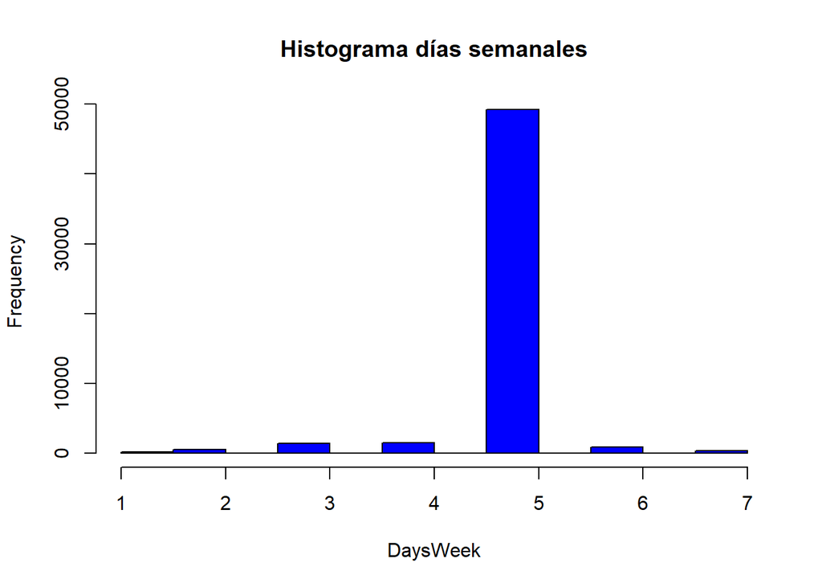

```r
seguros$WeeklyWages <- as.numeric(sub(",",".", seguros$WeeklyWages, fixed = TRUE))
seguros$HoursWeek <- as.numeric(sub(",",".", seguros$HoursWeek, fixed = TRUE))



hist(x = seguros$DaysWeek, main = "Histograma días semanales", xlab = "DaysWeek", ylab = "Frequency", col = "blue")
```

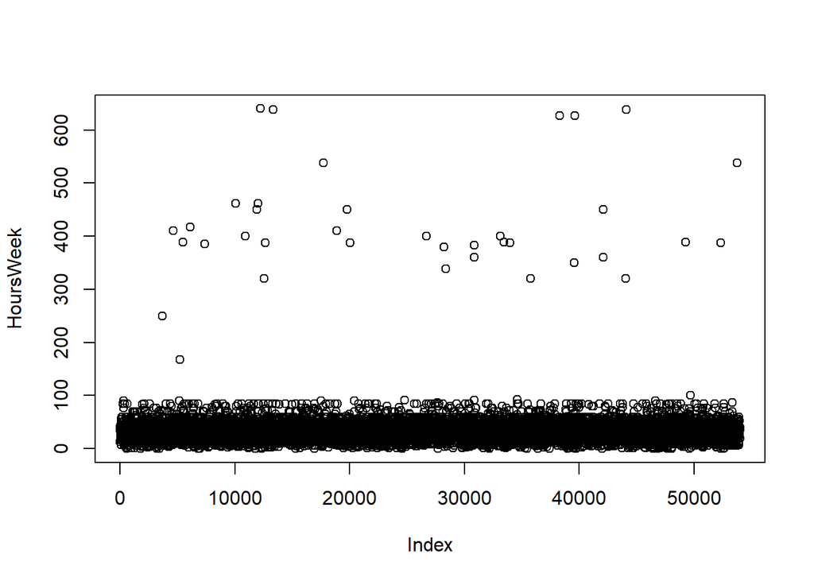

```r
plot(seguros$HoursWeek, ylab = "HoursWeek", xlab = "Index")
```

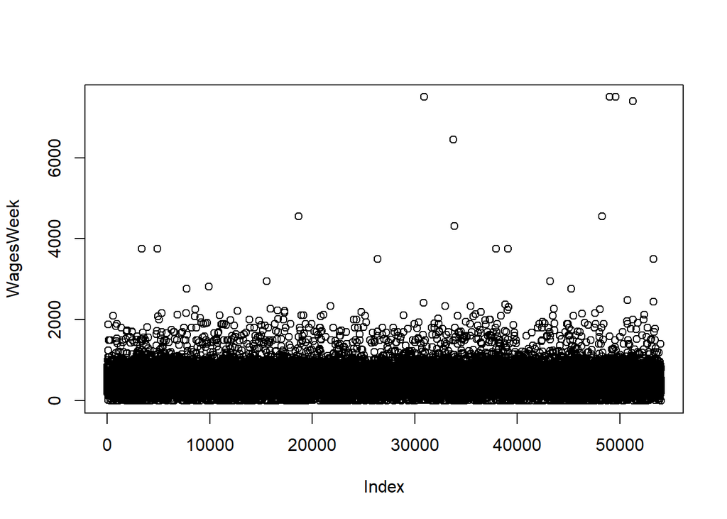

```r
plot(seguros$WeeklyWages, ylab = "WagesWeek", xlab = "Index")
```

# 6. Valores atípicos

Para comprobar los valores atípicos que puedan existir utilizaremos los diagramas de caja.

En primer lugar comprobaremos la variable Age:

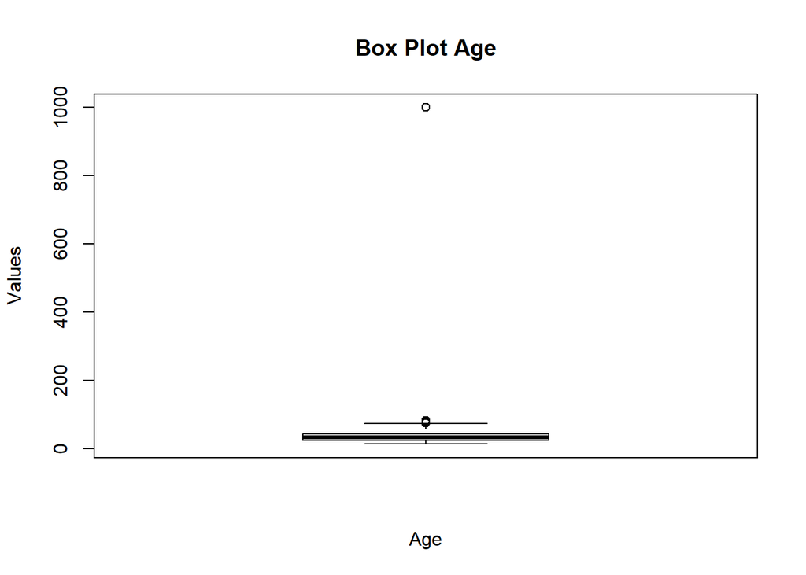

```r
boxplot(seguros$Age,main="Box Plot Age", col="gray",outbg="red",xlab = "Age", ylab="Values")
```

En el diagrama de cajas podemos observar que hay un valor extremo, el cual utilizaremos como valor centinela para el posterior reemplazo por el valor NA. Para esta variable reemplazaremos por el valor centinela aquellos valores inferiores a 0 y superiores a 100.

```r
val.centinela <- max(seguros$Age)
seguros$Age[seguros$Age > 100] = val.centinela
seguros$Age[seguros$Age < 0] = val.centinela

seguros$Age[seguros$Age == val.centinela] <- NA

summary(seguros$Age)
```

```
##    Min. 1st Qu.  Median    Mean 3rd Qu.    Max.    NA's
##   13.00   23.00   32.00   33.84   43.00   81.00      12
```

Podemos ver que se localizaron 12 valores atípicos.

Comprobamos la variable WeeklyWages :

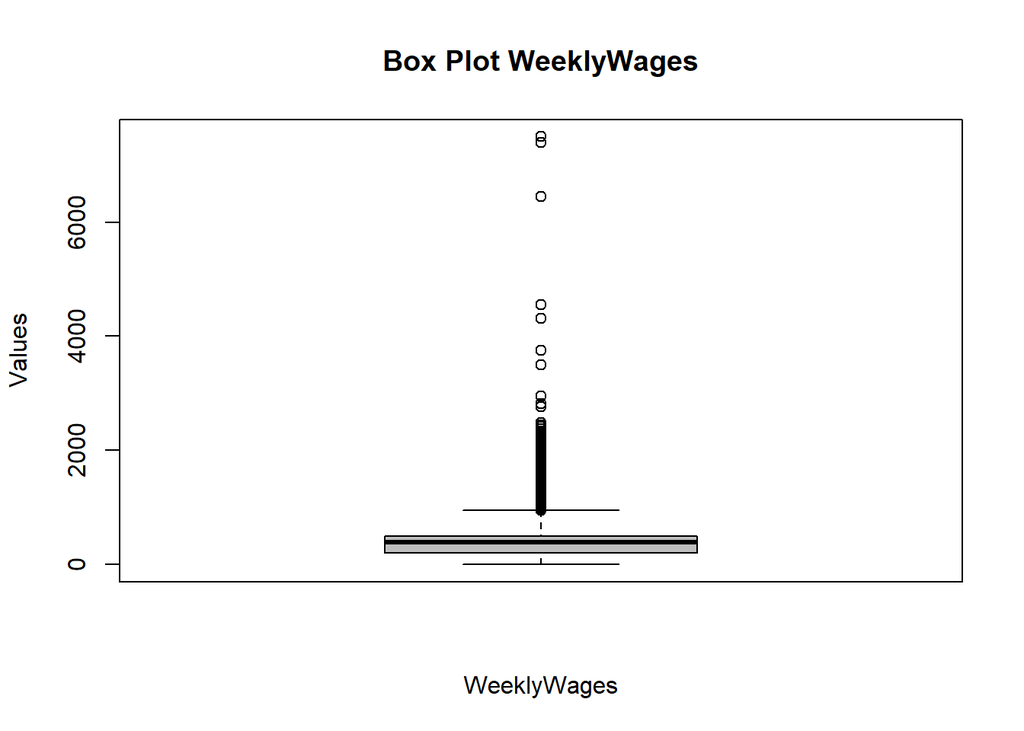

```r
boxplot(seguros$WeeklyWages,main="Box Plot WeeklyWages", col="gray", xlab = "WeeklyWages", ylab="Values" )
```

Podemos ver que existen varios valores atípicos para esta variable, consideraremos atípicos los valores superiores a 4000 y los inferiroes a 0, utilizaremos el valor máximo como valor centinela y lo reemplazamos por NA.

```r
val.centinela <- max(seguros$WeeklyWages)

seguros$WeeklyWages[seguros$WeeklyWages > 4000] = val.centinela
seguros$WeeklyWages[seguros$WeeklyWages < 0] = val.centinela

seguros$WeeklyWages[seguros$WeeklyWages == val.centinela] <- NA

summary(seguros$WeeklyWages)
```

```
##    Min. 1st Qu.  Median    Mean 3rd Qu.    Max.    NA's
##     1.0   200.0   392.2   415.5   500.0  3750.0       8
```

En este caso tenemos 8 valores atípicos.

Comprobamos la variable DaysWeek:

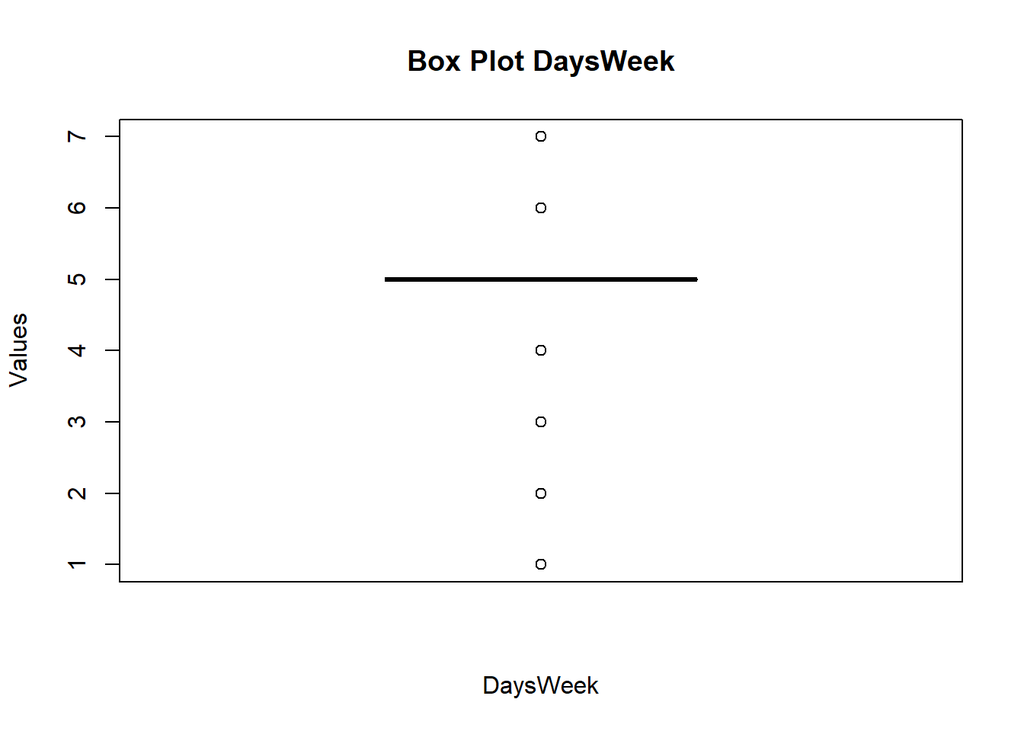

```r
boxplot(seguros$DaysWeek ,main="Box Plot DaysWeek", col="gray",xlab = "DaysWeek", ylab="Values")
```

Podemos observar que para esta variable no existen valores atípicos debido a que todos están entre 1 y 7 que corresponderían a los días de la semana, por lo tanto no es necesaria ninguna transformación.

Comprobamos la variable HoursWeek:

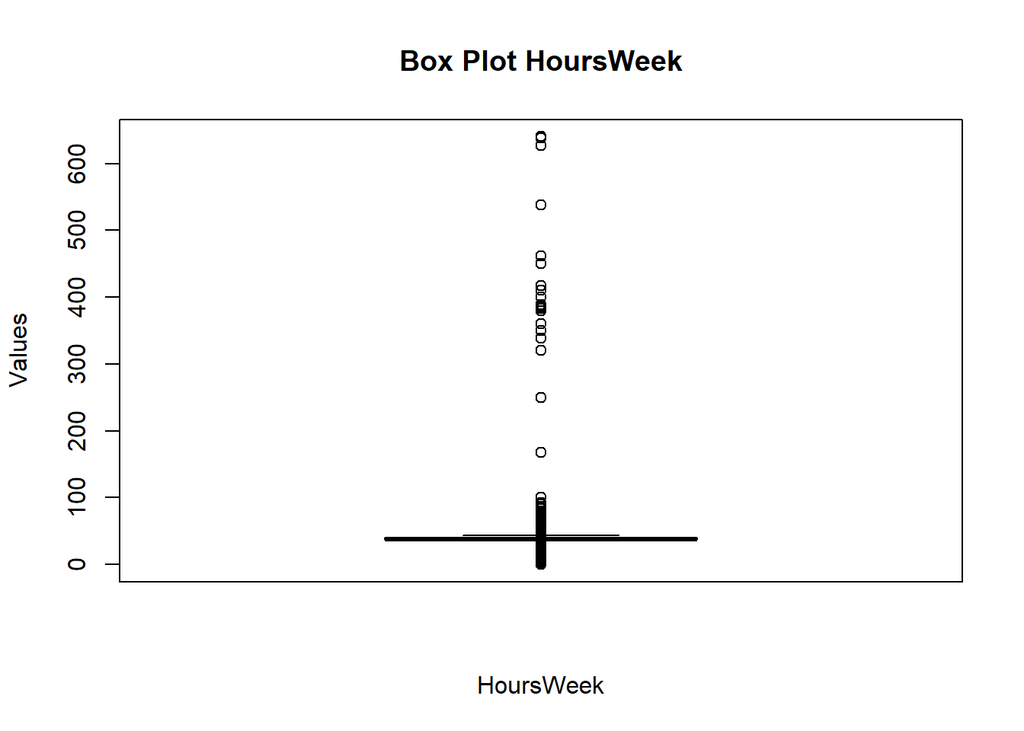

```r
boxplot(seguros$HoursWeek, main="Box Plot HoursWeek", col="gray", xlab = "HoursWeek", ylab = "Values")
```

Para este caso podemos ver que también hay varios valores atípicos, en este caso consideraremos atípicos aquellos valores superiores a 70, que sería el equivalente a trabajar 10 horas al día todos los días de la semana, y los valores inferiores a 0.

```r
val.centinela <- max(seguros$HoursWeek)
seguros$HoursWeek[seguros$HoursWeek > 70] = val.centinela
seguros$HoursWeek[seguros$HoursWeek < 0] = val.centinela

seguros$HoursWeek[seguros$HoursWeek == val.centinela] <- NA

summary(seguros$HoursWeek)
```

```
##    Min. 1st Qu.  Median    Mean 3rd Qu.    Max.    NA's
##    0.00   38.00   38.00   37.31   40.00   70.00     245
```

Para este caso tenemos bastantes valores atípicos, un total de 245.

Comprobamos la variable IniCost

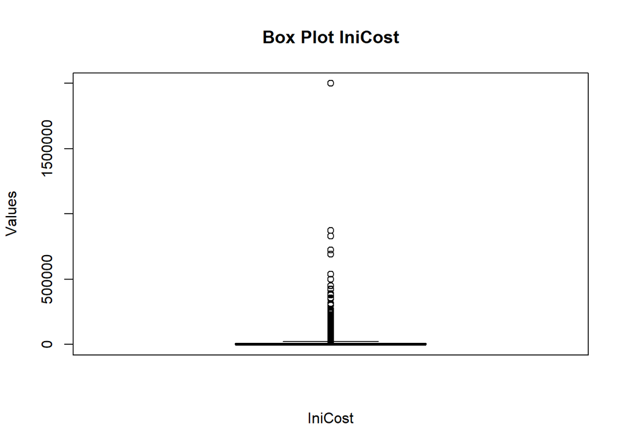

```r
boxplot(seguros$IniCost, main="Box Plot IniCost", col="gray", xlab = "IniCost", ylab = "Values")
```

Para esta variable vemos que hay un valor extremo y algunos valores atípicos, consideraremos atípicos aquellos valores superiroes a 500000 y menores a 0.

```r
val.centinela <- max(seguros$IniCost)
seguros$IniCost[seguros$IniCost > 500000] = val.centinela
seguros$IniCost[seguros$IniCost < 0] = val.centinela

seguros$IniCost[seguros$IniCost == val.centinela] <- NA

summary(seguros$IniCost)
```

```
##    Min. 1st Qu.  Median    Mean 3rd Qu.    Max.    NA's
##       1     700    2000    7722    9500  500000       7
```

Comprobamos la variable UltCost

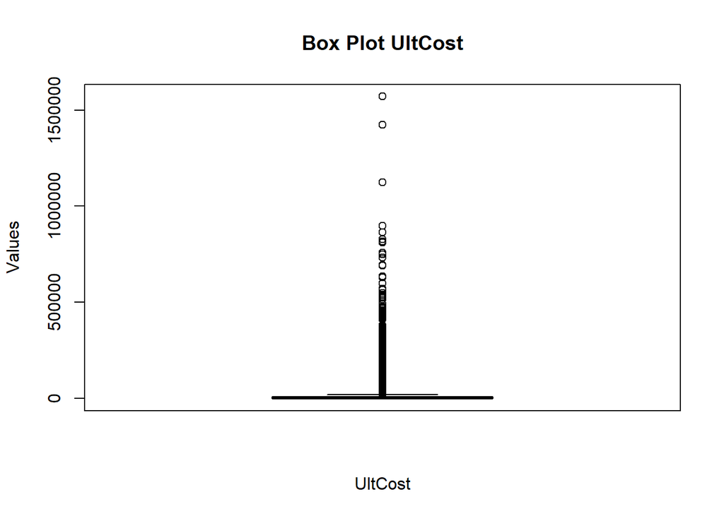

```r
boxplot(seguros$UltCost, main="Box Plot UltCost", col="gray", xlab = "UltCost", ylab = "Values")
```

En este caso vemos la existencia de varios valores extremos y de algunos valores atípicos, por eso consideraremos atípicos aquellos valores inferiroes a 0 y superiores a 750000.

```r
val.centinela <- max(seguros$UltCost)
seguros$UltCost[seguros$UltCost > 750000] = val.centinela
seguros$UltCost[seguros$UltCost < 0] = val.centinela

seguros$UltCost[seguros$UltCost == val.centinela] <- NA

summary(seguros$UltCost)
```

```
##    Min. 1st Qu.  Median    Mean 3rd Qu.    Max.    NA's
##       6    1128    3178   10015    8898  732687      10
```

# 7. Imputación de valores

Una vez obtenidos los valores anómalos vamos a realizar la imputación de estos, en primer lugar utilizaremos la media aritmética para la variable Age:

```r
seguros$Age[is.na(seguros$Age)] <- round(mean(seguros$Age, na.rm = TRUE))
levels(factor(seguros$Age))
```

```
##  [1] "13" "14" "15" "16" "17" "18" "19" "20" "21" "22" "23" "24" "25" "26" "27"
## [16] "28" "29" "30" "31" "32" "33" "34" "35" "36" "37" "38" "39" "40" "41" "42"
## [31] "43" "44" "45" "46" "47" "48" "49" "50" "51" "52" "53" "54" "55" "56" "57"
## [46] "58" "59" "60" "61" "62" "63" "64" "65" "66" "67" "68" "69" "70" "71" "72"
## [61] "73" "74" "75" "76" "78" "79" "80" "81"
```

Comprobamos que se han reemplazado los valores anómalos correctamente.

Para las variables IniCost, UltCost, DaysWeek, WeeklyWages y HoursWeek emplearemos la imputación por vecinos más cercanos, utilizando la distancia de Gower:

```r
column_names <- c('IniCost','UltCost','DaysWeek', 'WeeklyWages', 'HoursWeek')
seguros <- kNN(data = seguros, variable = column_names, k = 10, dist_var = 'Gender', imp_var = FALSE)
```

# 8. Preparación de los datos

## 8.1. Tiempo de abertura del expediente

Para poder calcular el tiempo que se tarda en abrir el expediente desde el suceso del accidente primero debemos transformar el tipo de dato de las ariables DateTimeOfAccident y dtReportered al tipo de dato Date, para poder realizar la conversión primero debemos de eliminar la hora de ámbas variables

```r
# Obtenenos la fecha sin la hora
dtAccident <- t(as.data.frame(strsplit(seguros$DateTimeOfAccident, "T")))
row.names(dtAccident) = NULL

dtReportered <- t(as.data.frame(strsplit(seguros$DateReported, "T")))
row.names(dtReportered) = NULL
```

Una vez tenemos sólo la fecha realizamos la conversión de las variables al tipo de dato Date:

```r
seguros$DateTimeOfAccident <- ymd(dtAccident[,1])

seguros$DateReported <- ymd(dtReportered[,1])
class(seguros$DateReported)
```

```
## [1] "Date"
```

```r
head(seguros$DateReported)
```

```
## [1] "2002-07-05" "1999-01-20" "1996-04-14" "2005-07-22" "1990-09-27"
## [6] "1999-09-09"
```

```r
class(seguros$DateTimeOfAccident)
```

```
## [1] "Date"
```

```r
head(seguros$DateTimeOfAccident)
```

```
## [1] "2002-04-09" "1999-01-07" "1996-03-25" "2005-06-22" "1990-08-29"
## [6] "1999-06-21"
```

Una vez comprobado que se ha realizado la conversión correctamente obtendremos la diferencia en días que existe entre la fecha en la que se reporta el accidente y la fecha en la que se produjo el accidente, almacenando esta información en una nueva variable que denominaremos Time.

```r
seguros$Time <- seguros$DateReported - seguros$DateTimeOfAccident
head(seguros$Time)
```

```
## Time differences in days
## [1] 87 13 20 30 29 80
```

## 8.2. Diferencia entre IniCost y UltCost

Igual que realizamos en el apartado anterior, obtendremos la diferencia entre el coste inicial y final y lo almacenamos en una nueva variable que denominaremos DifCost :

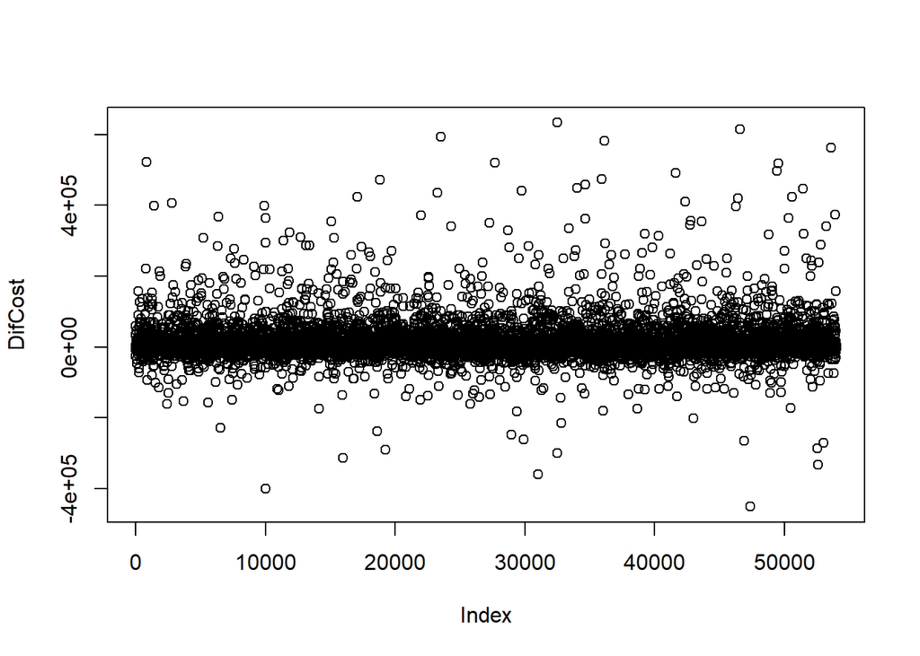

```r
seguros$DifCost <- seguros$UltCost - seguros$IniCost

#Mostramos la distribución de la diferencia entre el coste inicial y final
plot(seguros$DifCost, ylab = "DifCost", xlab = "Index")
```

# 9. Estudio descriptivo

## 9.1. Funciones de medida robustas

Para obtener medidas robustas de nuestros datos en pirmer lugar definimos una función que permita calcular la media recortada, dicha función se va a encargar de ordenar el vector de datos y posteriormente a eliminar los elementos necesarios al inicio y final de dicho vector para el calculo de la media:

```r
media.recortada <- function(x, perc=0.05 ){

  # Ordenamos el vector
  x <- sort(x, decreasing = FALSE, index.return = FALSE)
  # Obtenemos el número de elementos
  n <- length(x)

  # Obtenemso el número de elementos a eliminar al principio y al final del vector
  nValoresExluidos <- round(n * perc)
  indiceSuperior <- n - nValoresExluidos

  # Eliminamos del vector los primeros y últimos nValoresExcluidos
  x <-  x[nValoresExluidos:indiceSuperior]

 return(mean(x))
}
```

Por otro lado definimos una función que permita obtener la media winsor, dicha función se encargara de ordenar el vector y posteriormente sustituirá los elementos iniciales y finales por el valor de corte en ámbas partes del vector para el calculo de la media

```r
media.winsor <- function(x, perc=0.05){

    # Ordenamos el vector
  x <- sort(x, decreasing = FALSE, index.return = FALSE)
  # Obtenemos el número de elementos
  n <- length(x)

    # Obtenemso el número de elementos a sustituir al principio y al final del vector
  nValoresSustituir <- round(n * perc)

  #Obtenemos los valores por los que vamos a sustituir los nValoresSustutir al inicio y al final
  valorInferior <- x[nValoresSustituir + 1]
  valorSuperior <- x[n - nValoresSustituir - 1]
  indiceSuperior <- n - nValoresSustituir

  #SUstituimos los elementos
  for(i in 1:nValoresSustituir){
    x[i] <- valorInferior
  }

  for(i in indiceSuperior:n ){
    x[i] <- valorSuperior
  }

 return(mean(x))
}
```

## 9.2. Estudio descriptivo de las variables cuantitativas

Para realizar el estudio descriptivo calcularemos la media, la media recortada con precisión del 5% y del 20%, la media winsor con precisión del 5% y del 20% la mediana y los cuartiles de las variables:

```r
Age <- c(mean(seguros$Age),media.recortada(seguros$Age),media.recortada(seguros$Age, 0.20),media.winsor(seguros$Age),media.winsor(seguros$Age, 0.20), median(seguros$Age),quantile(seguros$Age),var(seguros$Age),sd(seguros$Age))

WeeklyWages <- c(mean(seguros$WeeklyWages),media.recortada(seguros$WeeklyWages), media.recortada(seguros$WeeklyWages, 0.20),media.winsor(seguros$WeeklyWages), media.winsor(seguros$WeeklyWages, 0.20),median(seguros$WeeklyWages),quantile(seguros$WeeklyWages),var(seguros$WeeklyWages),sd(seguros$WeeklyWages))

DaysWeek <- c(mean(seguros$DaysWeek),media.recortada(seguros$DaysWeek), media.recortada(seguros$DaysWeek, 0.20),media.winsor(seguros$DaysWeek), media.winsor(seguros$DaysWeek, 0.20),median(seguros$DaysWeek),quantile(seguros$DaysWeek),var(seguros$DaysWeek),sd(seguros$DaysWeek))

HoursWeek <- c(mean(seguros$HoursWeek),media.recortada(seguros$HoursWeek),media.recortada(seguros$HoursWeek,0.20),media.winsor(seguros$HoursWeek), media.winsor(seguros$HoursWeek, 0.20),median(seguros$HoursWeek),quantile(seguros$HoursWeek),var(seguros$HoursWeek),sd(seguros$HoursWeek))

IniCost <- c(mean(seguros$IniCost),media.recortada(seguros$IniCost),media.recortada(seguros$IniCost, 0.20),media.winsor(seguros$IniCost), media.winsor(seguros$IniCost,0.20),median(seguros$IniCost),quantile(seguros$IniCost),var(seguros$IniCost),sd(seguros$IniCost))

UltCost <- c(mean(seguros$UltCost),media.recortada(seguros$UltCost),media.recortada(seguros$UltCost,0.20),media.winsor(seguros$UltCost),media.winsor(seguros$UltCost,0.20),median(seguros$UltCost),quantile(seguros$UltCost),var(seguros$UltCost),sd(seguros$UltCost))

tablaDatos <- cbind (Age,WeeklyWages, DaysWeek,HoursWeek, IniCost, UltCost)
row.names(tablaDatos) <- c("Media", "Media recortada 5%", "Media recirtada 20%", "Media winsor 5%", "Media winsor 20%", "Mediana", "Cuartil 0", "Cuartil 25", "Cuartil 50", "Cuartil 75", "Cuartil 100", "Varianza", "Desviación")

tablaDatos
```

```
##                           Age WeeklyWages  DaysWeek HoursWeek      IniCost
## Media                33.84165    415.5081 4.9057593  37.30833 7.721267e+03
## Media recortada 5%   33.31711    394.5559 4.9812967  37.93092 5.098753e+03
## Media recirtada 20%  32.43724    378.7795 5.0000000  38.29367 3.448471e+03
## Media winsor 5%      33.68569    405.9040 4.9331852  37.25812 6.104716e+03
## Media winsor 20%     32.86254    376.8690 5.0000000  38.57621 4.169137e+03
## Mediana              32.00000    392.1950 5.0000000  38.00000 2.000000e+03
## Cuartil 0            13.00000      1.0000 1.0000000   0.00000 1.000000e+00
## Cuartil 25           23.00000    200.0000 5.0000000  38.00000 7.000000e+02
## Cuartil 50           32.00000    392.1950 5.0000000  38.00000 2.000000e+03
## Cuartil 75           43.00000    500.0000 5.0000000  40.00000 9.500000e+03
## Cuartil 100          81.00000   3750.0000 7.0000000  70.00000 5.000000e+05
## Varianza            146.90281  56542.1788 0.3048466  41.95347 2.879157e+08
## Desviación           12.12035    237.7860 0.5521291   6.47715 1.696808e+04
##                          UltCost
## Media               1.001368e+04
## Media recortada 5%  6.188767e+03
## Media recirtada 20% 4.035231e+03
## Media winsor 5%     7.526349e+03
## Media winsor 20%    4.894397e+03
## Mediana             3.178000e+03
## Cuartil 0           6.000000e+00
## Cuartil 25          1.128750e+03
## Cuartil 50          3.178000e+03
## Cuartil 75          8.894750e+03
## Cuartil 100         7.326870e+05
## Varianza            6.523501e+08
## Desviación          2.554115e+04
```

# 10. Archivo final

Exportamos los datos en un fichero csv:

```r
  write.csv2(seguros, "train_clean.csv")
```